# Agent-based Modelling Practical

Building an agent-based model of disease spread using Netlogo

## Introduction

In this session we’re going to have a go at building an *agent-based model* - or **ABM** for short. As we’ve discussed throughout the day, ABM are a very different approach to understanding social phenomena that seek to model the individual components of a system, and their actions and interactions, with the hope of better understanding how those individuals behaviours generate system wide outcomes. ABM can and have been used in a wide variety of domains and for a wide variety of purposes - and are currently regarded as one of the cutting edge simulation techniques. Of particular relevance here - the field of agent-based social simulation seeks to build ABM of social systems - modelling the actions and interactions of individual people and trying to understand how those actions and interactions influence societal outcomes.

In today’s exercise we will have a go at doing just that - by building a very simple model of disease spread - a topic that has undoubtedly been on most peoples minds at some point over the past few years.

For this exercise we will use an ABM development package called *Netlogo* that has been developed at Northwestern University in Chicago and is used all over the world to rapidly prototype ABM.

Let’s get into it.

### Step 0: Download, install and open Netlogo

Our initial step is to download and install Netlogo. Point your browser to [the Netlogo download page](https://ccl.northwestern.edu/netlogo/download.shtml) and hit the download button. Once you’ve downloaded the file, find it and double click to install netlogo - in windows this should be relatively self explanatory. On a mac you’ll need to open the Netlogo dmg file - then drag the Netlogo directory into your Applications folder.

Hopefully we all have Netlogo installed - now we need to open it. In finder (mac) or explorer (windows) find where you installed netlogo (or the shortcut to it) and double click on `Netlogo` (this is a red arrow on a blue/green background). Once it’s loaded you should see a screen that looks something like this (I’m on a mac - so windows users might look very slightly different).

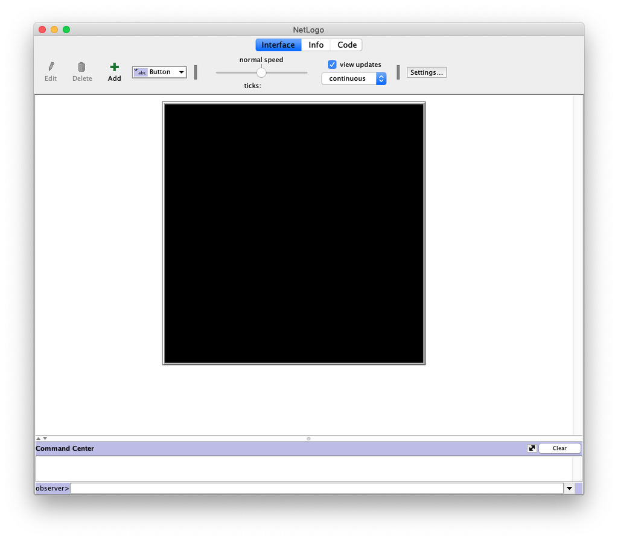

At the top of the Netlogo window you’ll see three tabs - Interface, Info and Code. These are the three main windows in Netlogo. For today we’re only really interested in Interface - where we currently are - and Code.

The interface tab is where we build the visual elements of our model and ultimately where we will run it and examine its behaviour. Netlogo allows users to combine a point and click interface which we build through the Interface tab with some programming that we enter in the Code tab.

To illustrate this point it’s probably best if we just get started building our model. But before we get started let’s have a little think about what we are going to try and simulate.

In the first instance I’d like us to build a very simple model of disease spread in a population. To that end, we want to do the following things.

- Create a population of agents who represent our population of people who might catch the disease.
- Create a simple environment for them to move around in
- Create behaviours that let them travel around that environment
- Create a behaviour that represents people passing some disease to one-another as they come in contact.
- Build some options into the model that allow us to specify:
  - the size or our population
  - the number of initially infected individuals
  - the likelihood that transmission occurs between two agents who come into contact with each
- Build some model elements that let us monitor over how many people in the model are infected.

OK - that’s a good start - let’s try and do the above and hopefully along the way we will learn how to use Netlogo and more generally what the ABM approach looks like.

### Step 1 - Creating our environment

Our first task is to tell Netlogo what the world in which our agents will interact looks like - so let’s do that now.

1. Go back to the interface window.
2. Right-click on the simulation display window - that’s the big black box where our simulation will be visualised - and select `edit`.
3. Set the world to be a 30x30 grid that wraps both horizontally and vertically with the origin in the bottom-left corner. All other defaults are OK (see image below).

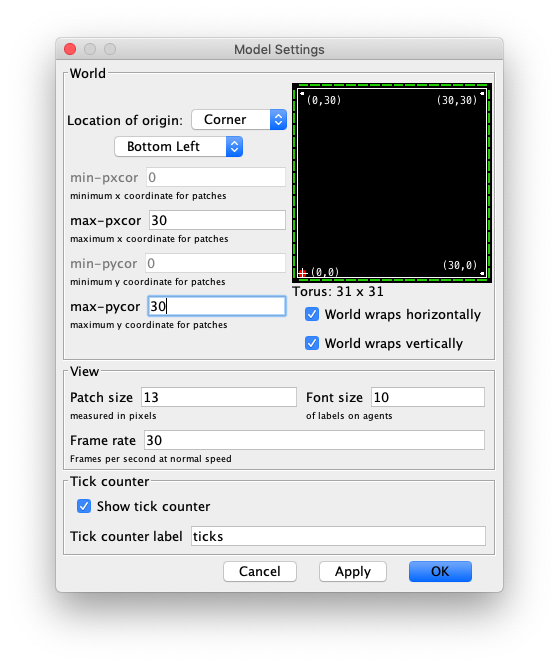

4. Click OK. Your environment is now ready.

### Step 2 -Create a button which will set-up the model.

1. Still in the interface tab click on the drop-down list next to “Add” and select “Button”
2. Move the mouse to where you would like the button to be and left-click to place it.
3. In the new menu that appears you can specify what the button should do. Enter “setup” in the commands box – this will mean that a procedure called “setup” is called when the button is clicked (we will create this procedure in a minute). The “Display Name” is a label for the button, you can set this to be whatever you want to. This process should look something like this ….

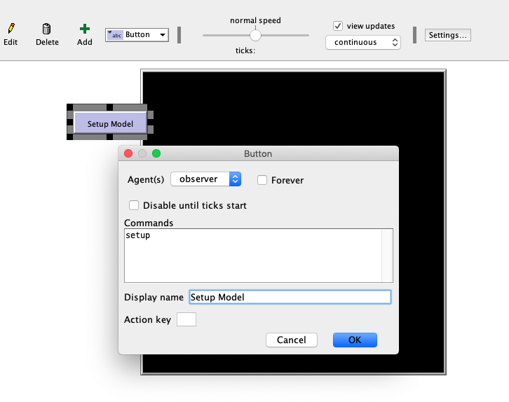

4. Click on OK to finish the button. You can see that the button is red which means it refers to a procedure that hasn’t been created yet, lets do that now.

### Step 3 - Creating the “setup” function

Now we’re going to create some code that tells Netlogo what to do when we press the setup button. To do this we need to move to the Code tab - to do this simply click on `Code` at the top of the application. You should see something like this:

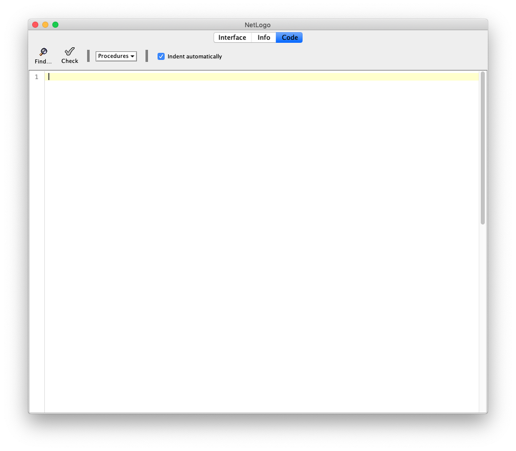

This window is where we will enter our code for the model - a bit like in RStudio (although considerably less sophisticated!). Note that whenever we write code we also try to write some comments which tell us in English what the code does - these comments are defined by placing a `;` character before the text we write. This tell netlogo that the following text is a comment and not part of our actual program code.

1. Enter the following text to define the “setup” function:

```
to setup
  print "Setting Up Model"
end
```

In Netlogo we start a function with the keyword `to` then add the name of the function, followed by the actual code itself. We then end this function definition with keyword `end`. All the function does so far is print a message using the `print` keyword.

2. To make sure our code is properly formatted we can press the ‘Check’ button in the top-left corner of the code tab. This will check our code for errors, and tell us if we have done something wrong. If you see an error message - check to make sure your code is formatted exactly the same as mine above.
3. Now let’s check this actually works by clicking on the “Interface” tab and then clicking on the `Setup Model` button - you should see a message displayed in the console a the bottom of the screen as Netlogo runs the `print` command inside your `setup` function.

### Step 4 - Creating a slider for the number of agents.

1. Lets add a slider so we can set the number of agents to create. This is the basically the same as creating a button, in the interface tab pick “slider” from the drop down menu and you choose where to add the new slider and then configure it.
2. The “Global variable” box is where you type in the name of the variable that the slider will change, call it `initial-number-of-agents`. We can then refer to this global variable in our functions.
3. You can set the minimum and maximum values and the amount the values should change as you move the slider around. Set the minimum to be 0 (no agents) and the maximum to be 100. We don’t make use of this slider yet, but we will do in a few steps.

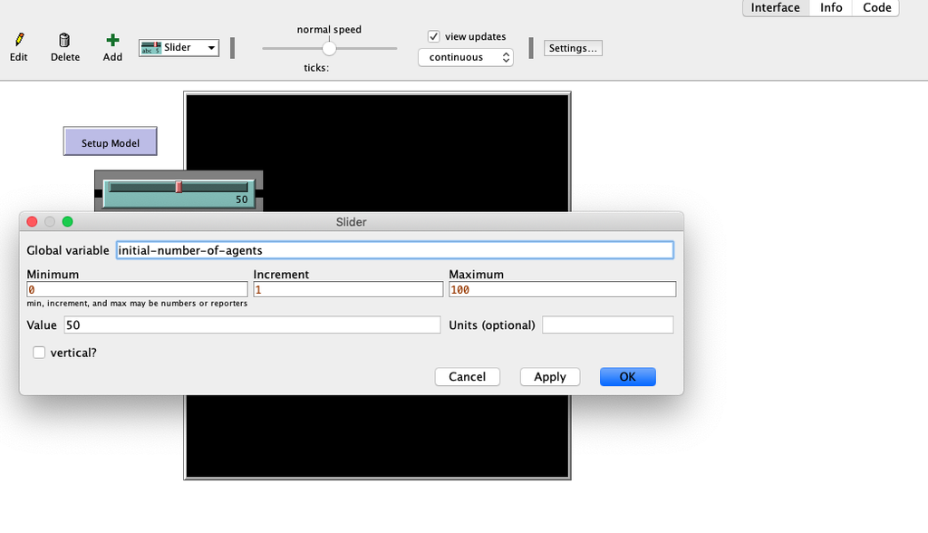

### Step 5 - Setting up the enviornment and agents.

1. Now we’ll improve the `setup` function so that it does something useful. Click on the code button again and change your setup function so it now reads:

```
to setup
  print "Setting Up Model"
  clear-all
  reset-ticks
  setup-patches
  setup-turtles
end
```

**Note:** In Netlogo an agent is referred to as a **turtle** - there is a long and somewhat complicated explanation for this - but all you need to remember is that when we talk about **turtles** in the code we are referring to agents. Similarly, if you imagine that the environment in which the agents live as a giant chessboard (one we defined as a 30x30 grid in step 1) - each square on that board is called a **patch**.

2. `clear-all` is a built-in NetLogo command that clears up everything ready for us to create a new model. `reset-ticks` is another built in function that resets the simulation ‘clock’.

**Note:** In ABM we simulate the occurrence of some phenomena over time. In Netlogo this measurement of time is referred to in `ticks` - think the ticks of a clock. These ticks are simulation cycles - at each tick each agent in the model performs their actions. Once all the agents are done the simulation clock ticks forward a single tick and we run the agents again - and so on ……

3. The other two lines actually call two new functions that will setup the turtles (agents) and the patches (environment). Here is the code for these two new functions, paste it after the “setup” function (note that anything after a ‘;’ is a comment and won’t be read by NetLogo).

```
to setup-patches
 ask patches [ set pcolor green ] ; Set all the patches' colour to green
end

to setup-turtles
  ; Create the number of agents specified by the slider
  create-turtles initial-number-of-agents [
    ; Here we can set the values for each of our turtles
    set shape "person" ; Make them look like people
    setxy (random 30) (random 30) ; Set the turtle's x,y coord somewhere randomly in the world
    set color blue ; Set it's colour
  ]
end
```

Your code tab should now look something like this…

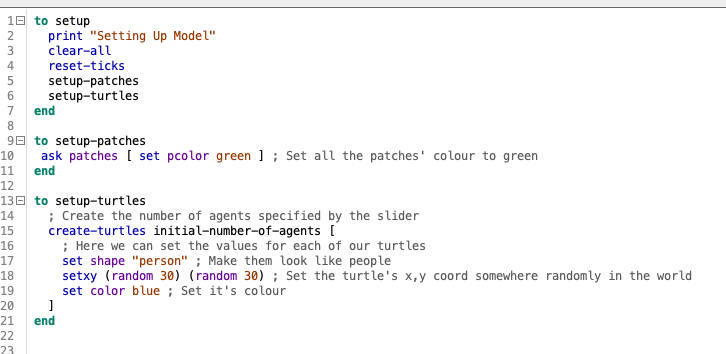

4. If you return to the interface tab and press the `setup model` button you should see a few agents created around the grid. If you keep pressing `setup model` the model will keep generating a new population and randomly placing them in the world - just like you specified. You can also play with the slider to control how many agents are created. Finally, you can also move interface elements around by clicking on them so you can tidy up your interface.

Your model should look something like this:

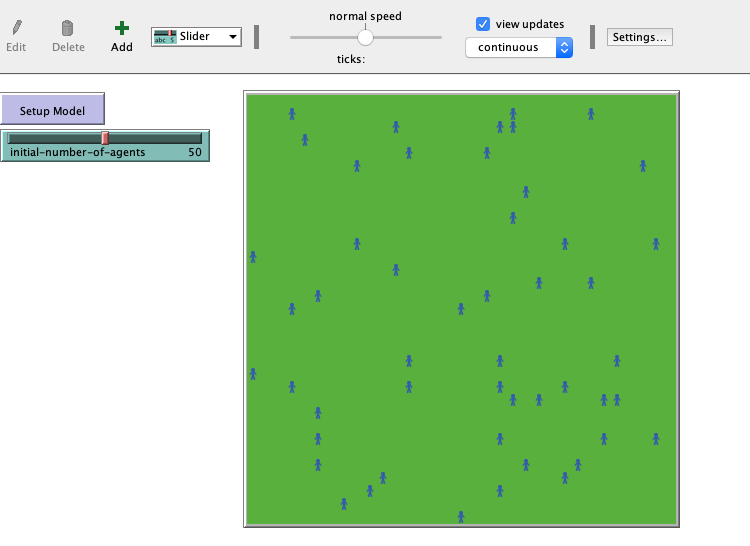

**Now’s a good time to save your model if you haven’t already done so. Click file, save, enter a name, and hit OK.**

### Step 6 - Creating a ‘go’ button which will run the simulation

1. To complete the first bit of our model we need to create a go button which will run the model. Create the button in the same way you created the setup button, but this time check the “Forever” box, this will call the function repeatedly.

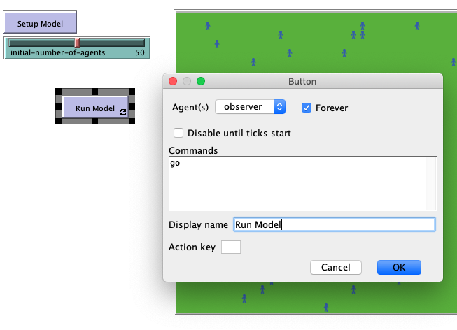

2. Add the code for the button by adding this with the other procedures in the code tab:

```
to go
  ; Go through each agent, tell them to move around
  ask turtles [
    ; Move one step in a random direction
    rt random 360 ; Face a random direction between 0 and 360 degrees
    fd 1          ; Go forward one step
  ]
  tick ; Increment the time counter
end
```

Go back to the interface tab hit `Setup Model` followed by `Run Model`. You should see your agents moving (very quickly) around the environment. To take a closer look you can reduce the speed of the model execution by pulling the `speed` slider to the left. You can stop the model running by clicking the `Run Model` button a second time.

Congratulations! You’ve just built your first ABM - a very simple simulation of people moving around. **Save it** (I’m going to stop reminding you now - but save frequently as we continue)

As fun as that was - now we need to extend this model to simulate the transmission of disease (less fun - in the real world at least). To do this we’re going to have to take a number of steps.

### Step 7 - Creating agent variables - infected status.

Our first task is to create the notion of an agent’s infection status. In our initial model we will let agents take on 2 different infection statuses: 1. Not-Infected 2. Infected

We’ll store this status for each agent in an agent variable - let’s do that now.

1. Return to the code tab and enter the following code at the top of the code window above your other functions.

```
turtles-own ;a list of turtle variables
[
 infection-status ; the infection status of the agent
]
```

The `turtles-own` command allows us to define a set of one or more variables that each agent in our model stores. Typically these relate to agent characteristics like age, or current wealth, and here infection status.

2. Now we have a variable to store infection status we’ll need to populate it when we first create our population. Go to the `setup-turtles` function and modify it to read:

```
to setup-turtles
  ; Create the number of agents specified by the slider
  create-turtles initial-number-of-agents [
    ; Here we can set the values for each of our turtles
    set shape "person" ; Make them look like people
    setxy (random 30) (random 30) ; Set the turtle's x,y coord somewhere randomly in the world
    set infection-status "Not-Infected"
    set color blue ; Set it's colour
  ]
end
```

3. Next we’ll setup the model so that one agent is initially infected - our patient zero. To do this, again we’ll modify the setup turtles function to read:

```
to setup-turtles
  ; Create the number of agents specified by the slider
  create-turtles initial-number-of-agents [
    ; Here we can set the values for each of our turtles
    set shape "person" ; Make them look like people
    setxy (random 30) (random 30) ; Set the turtle's x,y coord somewhere randomly in the world
    set infection-status "Not-Infected"
    set color blue ; Set it's colour
  ]
  ask one-of turtles [set infection-status "Infected" set color red]
end
```

You’ll notice that we added the command `ask one-of turtles [set infection-status "Infected" set color red]` - the start of this command `ask one-of turtles` tells netlogo that we want to select one agent at random. There are lots of keywords in Netlogo and you can access the Netlogo dictionary by clicking help and selecting Netlogo Dictionary at any time.

### Step 8 - Creating a transmission behaviour

Now we have a population and a patient zero we need to build a behaviour which simulates how agents might pass the disease on to one another. Here we will say that if 2 agents are at the same location (on the same patch) and one of them is infected there is a 20% chance they will pass the disease onto the non-infected patient.

1. To do this let’s create a new function called `check-transmission` that our infected agents will run each tick. In the code tab create a new function that reads

```
to check-transmission
  if any? turtles-here with [infection-status != "Infected"] ; first check to see if there are any other agents at your location that are not infected
  [
    let potential-infected one-of turtles-here ; if there are, select one of them

    if random-float 1 < 0.2 ; if a random number between 0 and 1 is less than 0.2 (i.e. 20%) of the time
    [
      ask potential-infected [ set infection-status "Infected" set color red ] ;infect that agent and color them red.
    ]
  ]
end
```

Read through this function following the comments so you understand what is happening. Two commands you’ll need to understand are `random-float 1` - this generates a random decimal number (called a floating point number in programming parlance) between 0 and 1 - like 0.456 or 0.11. The command `if` checks whether the statement following the `if` is true (in this case if the random number is less than 0.2) and if so runs the code in the […] square brackets.

2. Now let’s make our infected agents run this function each simulation tick. To do this, edit the `go` function to look like this:

```
to go
  ; Go through each agent, tell them to move around
  ask turtles [
    ; Move one step in a random direction
    rt random 360 ; Face a random direction between 0 and 360 degrees
    fd 1          ; Go forward one step

    if infection-status = "Infected" [ check-transmission ] ;infected agents check whether they transimit the disease

  ]
  tick ; Increment the time counter
end
```

That should do it - go back to the interface tab and setup and run the model. When the model starts you should be able to find one red agent. Over time as the model runs all agents will become infected - note that depending on how fast the model is running this will be difficult to watch happen, there will be almost no-one infected and then at some point everyone will be red. This has something to do with exponential growth.

To get a better idea of what is happening in the model we can build some graphs in the interface which will help us keep track of how many agents are infected. Let’s do that now.

### Step 9 - Building Model Monitors

1. In the interface tab, just like you added the buttons, you can also add a plot - do that by selecting plot from the drop-down menu and then clicking where you want the plot to be. Fill out the dialog box that appears to look like the one below. Here we are telling Netlogo to plot the count of turtles with `infection-status = "Infected"` - I’ve also set the colour of the line plotted by clicking on the colour box and selecting red.

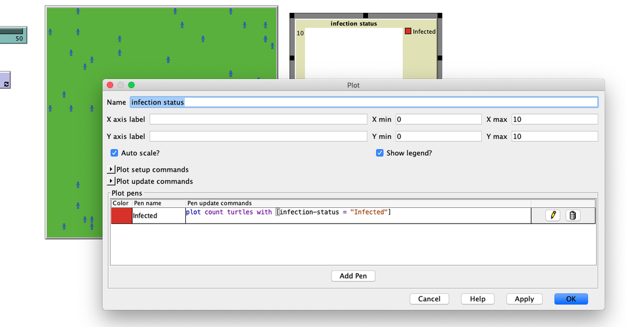

b. Click OK and return to the interface. Now select the plot and make it wider by dragging the right hand resize handle.

3. Setup and and re-run the model - watch the plot. Cool huh?
4. As a final step let’s also plot the number of agents not infected - we’ll use the same strategy. Edit our initial plot (by right clicking on it and selecting edit) and click the `Add Pen` button then fill it to include `plot count turtles with [infection-status = "Not-Infected"]`, name the pen `Not-Infected` and set the pen color to blue.

Again, setup and re-run the model - after some time the plot should look something like this (note that the number on the x-axis refers to the cycle count so below I took this screenshot after my model had run for 3430 cycles (or ticks!)…

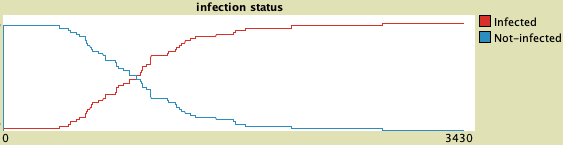

Makes sense, as the population infected rises the population of non-infected decreases.

### Step 10 - Adding Complexity.

Now we have a basic model it’s time to add some more complexity. In our current model people can become infected but then nothing happens. Obviously this ultimately leads to the entire population becoming infected. This isn’t really how diseases work so let’s try to make our model better reflect (a simplified version of) reality.

Generally speaking after people become infected with a disease one of at least two things can happen -

1. They recover and are immune to subsequent infection;
2. They recover and remain vulnerable to re-infection;

Let’s try to build this behaviour into the model. To do so we’ll need to make some more assumptions - for instance how long do people have the disease before one of the above things happen? what proportion of individuals become immune after recovery? and so on. These are what we call *model parameters*.

To model our fictional disease we’ll make some arbitrary assumptions. If we were building this model to answer a real research question we would eventually hope to get realistic estimates of these things - which we call *model calibration*. Nevertheless, we’ll assume the following.

- Once an agent is infected they have the disease for 500 ticks (you can already see that as the model would get more complicated we’d start to have to think about what a tick actually represented in real world time)
- After 500 ticks have elapsed and our agents recover, let’s say there is an 80% chance that they will develop immunity, and thus a 20% chance they will become vulnerable again.

Let’s break these behaviours down and start to think about how we might implement them.

First if we want to model the outcomes of an agent after 500 ticks of infection we’ll need agents that are infected to hold a variable that records the amount of time they have been infected. Let’s do that now.

1. In the code tab edit the `turtles-own` section include a variable called `infection-counter`. This section of your code should look like this:

```
turtles-own ;a list of turtle variables
[
 infection-status ; the infection status of the agent
 infection-counter ; the number of ticks an infected agent has been infected
]
```

2. Now we have created this agent variable, we’ll need to set it to 0 when agents are created. Let’s do that by adding the following line of code to our `setup-turtles` function after we set the `infection-status` variable:

```
set infection-counter 0
```

3. Good. Now we’ll need to setup a global-variable that sets the amount of time (500 ticks) that someone will have the disease. Like we did with setting the number of agents let’s make this a value we can change by creating a slider in the interface. Return to the interface tab, select slider from the dropdown menu, and add the slider. In the dialog box that appears call the variable `infection-time` and let it range from 1 to 1000 with a default value of 500. It should end up looking something like this….

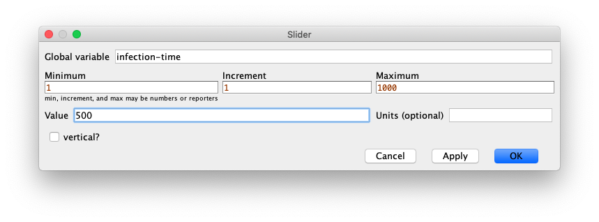

4. Now we need to add a behaviour that allows agents who are infected to count up how long they have been infected - and then at 500 clicks produce a new outcome (i.e. let them recover and them become immune or not). To start we will add a new function to increment an agent’s `infection-counter` each tick they are infected. In the code tab create a new function called `check-infection` that looks like this:

```
to check-infection
  ;take the current value of an agent's infection counter adds 1 and put the value back in infection-counter
  set infection-counter infection-counter + 1 ;

  ;now let's check if the infection-counter has reached the value stored in infection-timer.
  if infection-counter = infection-time
  [
      ; this agent survives - now we need to work out if they are
      ifelse random-float 1 < 0.8
      [
        ;this agent is immune
        set infection-status "Immune"
        set color white
        set infection-counter 0
      ]
      [
        ;this agent has recovered but can be re-infected
        set infection-status "Not-Infected"
        set color blue
        set infection-counter 0
      ]
  ]
end
```

Again, read through this function following the comments so you understand what is happening - it’s fairly simple. The only new command you should see is `ifelse` which is a modification of the `if` command we saw earlier that checks whether something is true and if so runs the code in the first set of […] square brackets. Otherwise it runs the code in the second set of square brackets (the ‘else’).

We now need to get those agents who are infected to run the `check-infection` function each cycle. To do that edit the line in the `go` function from

```
if infection-status = "Infected" [ check-transmission ]
```

to

```
if infection-status = "Infected"
[
  check-transmission  ;infected agents check whether they transimit the disease
  check-infection     ;infected agents check their own infection status
]
```

5. We’re getting there, but there a few things little we need to do finish up this functionality. Firstly, in our current `check-transmission` we haven’t said anything about agents who are immune, so currently they can still catch the virus. Our current code reads:

```
if any? turtles-here with [infection-status != "Infected"]
```

This says if there is someone here who does not have `infection-status` equal to “Infected” (denoted by `!=`) they can be infected. But this doesn’t account for our agents who have the `infection-status` equal to `"Immune"`. A better way to do this is to check to see if there are any agents that have the status = `"Not-Infected"`. So it reads like this:

```
if any? turtles-here with [infection-status = "Not-Infected"]
```

6. OK - nearly there - the last thing we are going to do is alter our plot to let us see how many agents are immune. To do this we’ll do what we did earlier and add another pen to the plot for immune agents. You should edit the plot options to look like this (again, edit the plot by right clicking on it and pressing edit)

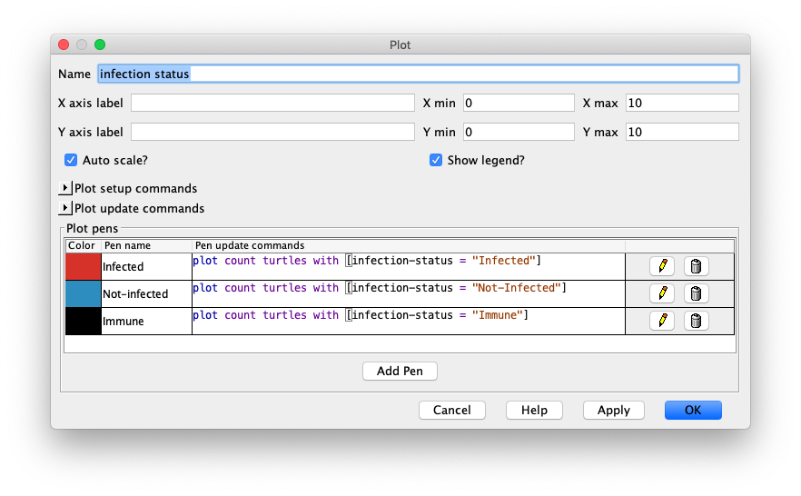

### Running the model and observing the system

OK, great we’re now at the point where we have a rudimentary model capable of representing the dynamics of disease spread - albeit in a very simplified way.

Run your model - look at what happens. Note that because the model contains a number of random elements - like the chance of a person getting infected / recovering / becoming immune etc - every time you run it it will produce different outcomes - in modelling parlance we call this model behaviour *non-deterministic*. And it means that ultimately we have to run a model lots of times to look at the range of outcomes that can emerge under a series of parameter values.

Once you’ve run it a few times play with the slider values to change the size of the population and the length of time agents are infected. You will see how changes to these values can produce very different outcomes - and that is how we start to understand how these things influence the severity of a pandemic.

Some observations: * With the default values you may often not see a pandemic at all. For instance as we only start with 1 infected person, there is a good chance that patient-zero will not infect anyone. If we increase the number of agents in the model this chance goes down - because people encounter each other more often. Similarly, if we increase the infection-time, the chance of spread goes up as infected agents present risk of transmission for longer periods of time.

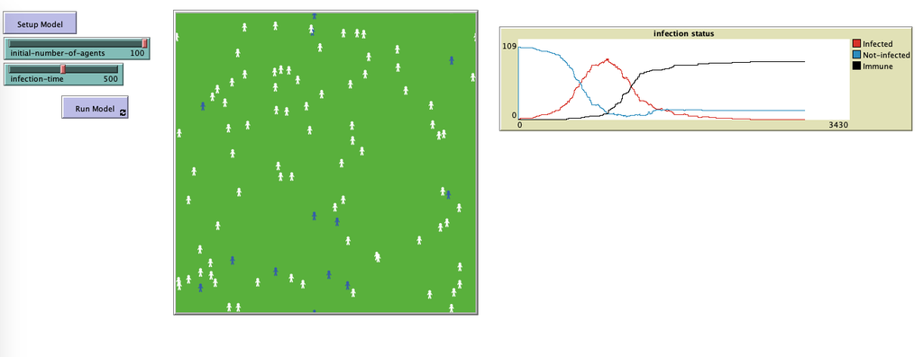

*Our model producing the classic ‘herd immunity’ phenomena.*

### Conclusion & Extensions

Hopefully this session has provided you with an interesting introduction to the use of agent-based models. If you are still interested there are a whole host of things you can do to modify your existing model. Some suggestions follow:

To implement some of these ideas you will need to use code that we haven’t covered above. To help you along your way remember that you can access the Netlogo dictionary by clicking ‘Help’ in the Netlogo application and selecting ‘Netlogo Dictionary’ at any time.

#### Parameterise and examine the impacts of varying rates of infection and recovery

Up to this point we have simply plucked numbers out of the air to parameterise our model. That is, we said that there is a 20% chance of transmission and 80% chance of immunity etc. What happens if that number changes, or better yet, we get real world data to calibrate it. Just like we setup a slider for the number of agents, we could do the same for the chance of transmission, the chances of immunity, and the number of people who initially have the disease.

You can implement these types of behaviours by editing the parts of the code where we check against some ‘hard-coded’ parameter (like the 0.2 representing a 20% chance of infection) and instead tell Netlogo to call on a variable set in a slider in the interface.

With our new parameterised model we could examine various configurations and examine how they impact on outcomes.

#### Estimating R0

R0, pronounced “R naught,” is a mathematical term that represents how contagious an infectious disease is - you’ve probably heard people talking about it a lot recently. R0 is a measure of the average number of people who will contract a contagious disease from one person with that disease. Using the simulation we could calculate R0 and examine how it might change under varying parameter conditions. To do this would require you to do the following things:

1. Create an agent variable `count-infections` that stores the number of people an infected agent has transmitted the disease to.
2. Increment that variable whenever an agent infects another (do this in the `check-transmission` function).
3. Create what is called a ‘monitor’ in the model interface (add it using the same drop down as the other interface elements).
4. In that monitor report the average value of your infection count variable across all infected agents - the syntax for that bit would look something like: `mean [count-infections] of turtles with [infection-status = "Infected"]`

#### Use the model to start to explore the impact of measures designed to reduce the impact of the disease.

In the real real world we might try to reduce the impact of a disease by controlling and isolating individuals who become infected, or more generally the population at large to reduce the likelihood of the disease spreading.

We could build these behaviours into the model by altering the movement behaviours of those infected (in the case of a simulated quarantine) or the population at large (social distancing anyone!). We could then test these scenarios in our model and see how effective they might be in reducing the spread of the disease.

Alternatively, you could build a model with a vaccine that could be given to some proportion of the population. This could be done at the start of the model, or if you wanted to make the model more realistic vaccination could be a rolling process with some proportion of agents vaccinated each cycle.

Remember that you can access the Netlogo dictionary by clicking help and selecting Netlogo Dictionary at any time.